# Analysis of SSA Dataset (Baby names) - Aditya Surana

```python
import pandas as pd
```

**Importing pandas for reading DataFrame**

```python
import matplotlib.pyplot as plt
%matplotlib inline
```

**Importing matplotlib.pyplot as plt**

```python
fout=open("population_names.csv","a")
for num in range(1880,2018):
    f = open("yob"+str(num)+".txt")
    for line in f:
         fout.write(line)
    f.close()
fout.close()
```

**Collecting all yob_.txt file in one "population_names.csv"**

```python
df = pd.read_csv('population_names.csv',names=['Name','Sex','No. of occurence of names'])
```

**Reading DataFrame as df and giving column names**

```python
df.head()
```

|  | Name | Sex | No. of occurence of names |
| --- | --- | --- | --- |
| 0 | Mary | F | 7065 |
| 1 | Anna | F | 2604 |
| 2 | Emma | F | 2003 |
| 3 | Elizabeth | F | 1939 |
| 4 | Minnie | F | 1746 |

```python
df.info()
```

```
<class 'pandas.core.frame.DataFrame'>
RangeIndex: 28869975 entries, 0 to 28869974
Data columns (total 3 columns):
Name                         object
Sex                          object
No. of occurence of names    int64
dtypes: int64(1), object(2)
memory usage: 660.8+ MB
```

**Getting information about the DataFrame**

```python
df.describe()
```

|  | No. of occurence of names |
| --- | --- |
| count | 2.886998e+07 |
| mean | 1.808733e+02 |
| std | 1.533337e+03 |
| min | 5.000000e+00 |
| 25% | 7.000000e+00 |
| 50% | 1.200000e+01 |
| 75% | 3.200000e+01 |
| max | 9.968600e+04 |

```python
df['No. of occurence of names'].max()
```

```
99686
```

**Getting the maximum No. of occurence of names**

```python
df['No. of occurence of names'].min()
```

```
5
```

**Getting the minimum No. of occurence of names**

```python
df[df['No. of occurence of names']==99686]['Name']
```

```
431064      Linda
2355729     Linda
4280394     Linda
6205059     Linda
8129724     Linda
10054389    Linda
11979054    Linda
13903719    Linda
15828384    Linda
17753049    Linda
19677714    Linda
21602379    Linda
23527044    Linda
25451709    Linda
Name: Name, dtype: object
```

**Name Linda occured for the max from all the year**

```python
df[df['No. of occurence of names']==5]['Name']
```

```
835             Adelle
836              Adina
837           Adrienne
838          Albertine
839               Alys
840                Ana
841           Araminta
842             Arthur
843             Birtha
844              Bulah
845             Caddie
846              Celie
847          Charlotta
848              Clair
849         Concepcion
```

[output cut: 47 more lines]

**These are the list of names which occured for minimum(5 times) from all the year**

**Loading DataFrame for 2010 as df_2010 :-**

```python
df_2010 = pd.read_csv('yob2010.txt',names=['Name','Sex','No. of occurence of names'])
```

```python
df_2010.head()
```

|  | Name | Sex | No. of occurence of names |
| --- | --- | --- | --- |
| 0 | Isabella | F | 22905 |
| 1 | Sophia | F | 20639 |
| 2 | Emma | F | 17338 |
| 3 | Olivia | F | 17022 |
| 4 | Ava | F | 15429 |

**Getting top5 entries of DataFrame**

```python
df_2010.info()
```

```
<class 'pandas.core.frame.DataFrame'>
RangeIndex: 34067 entries, 0 to 34066
Data columns (total 3 columns):
Name                         34067 non-null object
Sex                          34067 non-null object
No. of occurence of names    34067 non-null int64
dtypes: int64(1), object(2)
memory usage: 798.5+ KB
```

**Info of DataFrame**

```python
df_2010sorted = df_2010.sort_values('No. of occurence of names',ascending=False)
```

**Sorting the column 'No. of occurence of names' of DataFrame:df_2010 in descending order and storing it in df_2010sorted**

```python
df_2010sorted[df_2010sorted['Sex']=='F'].head(10)
```

|  | Name | Sex | No. of occurence of names |
| --- | --- | --- | --- |
| 0 | Isabella | F | 22905 |
| 1 | Sophia | F | 20639 |
| 2 | Emma | F | 17338 |
| 3 | Olivia | F | 17022 |
| 4 | Ava | F | 15429 |
| 5 | Emily | F | 14268 |
| 6 | Abigail | F | 14243 |
| 7 | Madison | F | 13176 |
| 8 | Chloe | F | 11750 |
| 9 | Mia | F | 10637 |

Getting top 10 most popular girl names; top 10 most popular girl names are:  
Isabella  
Sophia  
Emma  
Olivia  
Ava  
Emily  
Abigail  
Madison  
Chloe  
Mia

```python
df_2001 = pd.read_csv('yob2001.txt',names=['Name','Sex','No. of occurence of names'])
```

**Loading DataFrame for 2001 as df_2001**

```python
df_2001.head()
```

|  | Name | Sex | No. of occurence of names |
| --- | --- | --- | --- |
| 0 | Emily | F | 25055 |
| 1 | Madison | F | 22164 |
| 2 | Hannah | F | 20712 |
| 3 | Ashley | F | 16526 |
| 4 | Alexis | F | 16401 |

**Getting top5 entries of DataFrame**

```python
df_2001.info()
```

```
<class 'pandas.core.frame.DataFrame'>
RangeIndex: 30269 entries, 0 to 30268
Data columns (total 3 columns):
Name                         30269 non-null object
Sex                          30269 non-null object
No. of occurence of names    30269 non-null int64
dtypes: int64(1), object(2)
memory usage: 709.5+ KB
```

**Info of DataFrame**

```python
df_2001sorted = df_2001.sort_values('No. of occurence of names',ascending=False)
```

**Sorting the column 'No. of occurence of names' of DataFrame:df_2001 in descending order and storing it in df_2001sorted**

```python
df_2001sorted[df_2001sorted['Sex']=='M'].head(10)
```

|  | Name | Sex | No. of occurence of names |
| --- | --- | --- | --- |
| 17970 | Jacob | M | 32541 |
| 17971 | Michael | M | 29681 |
| 17972 | Matthew | M | 26806 |
| 17973 | Joshua | M | 26013 |
| 17974 | Christopher | M | 23123 |
| 17975 | Nicholas | M | 22842 |
| 17976 | Andrew | M | 22406 |
| 17977 | Joseph | M | 22004 |
| 17978 | Daniel | M | 20984 |
| 17979 | William | M | 20099 |

Getting top 10 most popular boy names; top 10 most popular boy names are:  
Jacob  
Michael  
Matthew  
Joshua  
Christopher  
Nicholas  
Andrew  
Joseph  
Daniel  
William

```python
for yr in range(2001,2011):
    df_yr = pd.read_csv("yob"+str(yr)+".txt",names=['Name','Sex','No. of occurence of names'])
    df_yrsorted = df_yr.sort_values('No. of occurence of names',ascending=False)
    print("\033[1m""Top 5 most popular names and their details of year "+str(yr)+"\033[0;0m")
    print(df_yrsorted.head())
```

```
Top 5 most popular names and their details of year 2001
          Name Sex  No. of occurence of names
17970    Jacob   M                      32541
17971  Michael   M                      29681
17972  Matthew   M                      26806
17973   Joshua   M                      26013
0        Emily   F                      25055
Top 5 most popular names and their details of year 2002
          Name Sex  No. of occurence of names
18081    Jacob   M                      30568
18082  Michael   M                      28246
18083   Joshua   M                      25986
18084  Matthew   M                      25151
0        Emily   F                      24463
Top 5 most popular names and their details of year 2003
```

[output cut: 55 more lines]

**Reading data from 2001 to 2010 files and then sorting the column 'No. of occurence of names' for all DataFrame in descending order then getting top5 entries from it.**  
**Note: above "\033[1m","\033[0;0m" is used to get 'bold' text**

```
For year 1880:-
      Name  No. of occurence of names
0  Michael                        354
1     John                       9655
2    David                        869
3   Martin                        357
For year 1881:-
      Name  No. of occurence of names
0  Michael                        298
1     John                       8769
2    David                        750
3   Martin                        327
For year 1882:-
      Name  No. of occurence of names
0  Michael                        321
1     John                       9557
2    David                        838
3   Martin                        387
For year 1883:-
      Name  No. of occurence of names
0  Michael                        307
1     John                       8894
2    David                        734
3   Martin                        377
For year 1884:-
      Name  No. of occurence of names
0  Michael                        373
1     John                       9388
2    David                        761
3   Martin                        385
For year 1885:-
      Name  No. of occurence of names
0  Michael                        370
1     John                       8756
2    David                        712
3   Martin                        357
For year 1886:-
      Name  No. of occurence of names
0  Michael                        348
1     John                       9026
```

[output cut: 773 more lines]

```
1     John                      10373
2    David                      11781
3   Martin                       1341
For year 2016:-
      Name  No. of occurence of names
0  Michael                      14057
1     John                       9995
2    David                      11089
3   Martin                       1394
For year 2017:-
      Name  No. of occurence of names
0  Michael                      12579
1     John                       9434
2    David                      10124
3   Martin                       1276
```

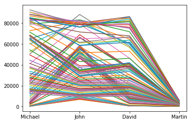

```python
for year in range(1880,2018):
    df_year = pd.read_csv("yob"+str(year)+".txt", names=['Name','Sex','No. of occurence of names'])
    a_year = int(df_year[(df_year['Name']=='Michael')&(df_year['Sex']=='M')]['No. of occurence of names'].get_values())
    b_year = int(df_year[(df_year['Name']=='John')&(df_year['Sex']=='M')]['No. of occurence of names'].get_values())
    c_year = int(df_year[(df_year['Name']=='David')&(df_year['Sex']=='M')]['No. of occurence of names'].get_values())
    d_year = int(df_year[(df_year['Name']=='Martin')&(df_year['Sex']=='M')]['No. of occurence of names'].get_values())
    data = {'Name':pd.Series(['Michael','John','David','Martin']),'No. of occurence of names':pd.Series([a_year,b_year,c_year,d_year])}
    df_boy = pd.DataFrame(data)
    print("\033[1m""For year "+str(year)+":-""\033[0;0m")
    print(df_boy.head())
    print(plt.plot(df_boy['Name'],df_boy['No. of occurence of names']))
```

**Reading data from (yob1880.txt to yob2017.txt file), then extracting 'No. of occurence of names' for Name_=['Michael','John','David','Martin'] after that creating new dataframe('df_boy') using the data and then lastly plotting the graph**  
**Note: Graph shown at last contains plot for all years**

```
For year 1880:-
        Name  No. of occurence of names
0      Emily                        210
1       Anna                       2604
2     Claire                         21
3  Elizabeth                       1939
For year 1881:-
        Name  No. of occurence of names
0      Emily                        244
1       Anna                       2698
2     Claire                         23
3  Elizabeth                       1852
For year 1882:-
        Name  No. of occurence of names
0      Emily                        272
1       Anna                       3143
2     Claire                         30
3  Elizabeth                       2186
For year 1883:-
        Name  No. of occurence of names
0      Emily                        342
1       Anna                       3306
2     Claire                         38
3  Elizabeth                       2255
For year 1884:-
        Name  No. of occurence of names
0      Emily                        364
1       Anna                       3860
2     Claire                         33
3  Elizabeth                       2549
For year 1885:-
        Name  No. of occurence of names
0      Emily                        346
1       Anna                       3994
2     Claire                         49
3  Elizabeth                       2582
For year 1886:-
        Name  No. of occurence of names
0      Emily                        369
1       Anna                       4283
```

[output cut: 773 more lines]

```
1       Anna                       5125
2     Claire                       4827
3  Elizabeth                       9724
For year 2016:-
        Name  No. of occurence of names
0      Emily                      10957
1       Anna                       4775
2     Claire                       5207
3  Elizabeth                       9542
For year 2017:-
        Name  No. of occurence of names
0      Emily                       9746
1       Anna                       4520
2     Claire                       4683
3  Elizabeth                       8915
```

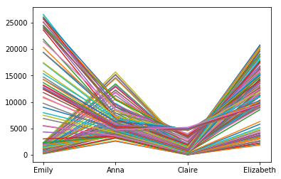

```python
for year in range(1880,2018):
    df_year = pd.read_csv("yob"+str(year)+".txt", names=['Name','Sex','No. of occurence of names'])
    a_year = int(df_year[(df_year['Name']=='Emily')&(df_year['Sex']=='F')]['No. of occurence of names'].get_values())
    b_year = int(df_year[(df_year['Name']=='Anna')&(df_year['Sex']=='F')]['No. of occurence of names'].get_values())
    c_year = int(df_year[(df_year['Name']=='Claire')&(df_year['Sex']=='F')]['No. of occurence of names'].get_values())
    d_year = int(df_year[(df_year['Name']=='Elizabeth')&(df_year['Sex']=='F')]['No. of occurence of names'].get_values())
    data = {'Name':pd.Series(['Emily','Anna','Claire','Elizabeth']),'No. of occurence of names':pd.Series([a_year,b_year,c_year,d_year])}
    df_girl = pd.DataFrame(data)
    print("\033[1m""For year "+str(year)+":-""\033[0;0m")
    print(df_girl.head())
    print(plt.plot(df_girl['Name'],df_girl['No. of occurence of names']))
```

**Reading data from (yob1880.txt to yob2017.txt file), then extracting 'No. of occurence of names' for Name_=['Emily','Anna','Claire','Elizabeth'] after that creating new dataframe('df_girl') using the data and then lastly plotting the graph**  
**Note: Graph shown at last contains plot for all years**

```python
import cufflinks as cf
import plotly.plotly as py
import plotly.graph_objs as go
from plotly.offline import download_plotlyjs, init_notebook_mode, plot, iplot
init_notebook_mode(connected=True)
cf.go_offline()
```

**Importing cufflink and plotly for making iplots**  
**Note: Cufflink connects plotly with pandas to create graphs and charts of dataframes directly**

```python
for year in range(1880,2018):
    df_year = pd.read_csv("yob"+str(year)+".txt", names=['Name','Sex','No. of occurence of names'])
    a_year = int(df_year[(df_year['Name']=='Michael')&(df_year['Sex']=='M')]['No. of occurence of names'].get_values())
    b_year = int(df_year[(df_year['Name']=='John')&(df_year['Sex']=='M')]['No. of occurence of names'].get_values())
    c_year = int(df_year[(df_year['Name']=='David')&(df_year['Sex']=='M')]['No. of occurence of names'].get_values())
    d_year = int(df_year[(df_year['Name']=='Martin')&(df_year['Sex']=='M')]['No. of occurence of names'].get_values())
    data = {'Name':pd.Series(['Michael','John','David','Martin']),'No. of occurence of names':pd.Series([a_year,b_year,c_year,d_year])}
    df_boy = pd.DataFrame(data)
    print(df_boy["No. of occurence of names"].iplot())
```

[interactive chart not shown]

```
None
```

[interactive chart not shown]

```
None
```

[interactive chart not shown]

```
None
```

[interactive chart not shown]

```
None
```

[interactive chart not shown]

```
None
```

[interactive chart not shown]

```
None
```

[interactive chart not shown]

```
None
```

[interactive chart not shown]

```
None
```

[interactive chart not shown]

```
None
```

[interactive chart not shown]

```
None
```

[interactive chart not shown]

```
None
```

[interactive chart not shown]

```
None
```

[interactive chart not shown]

```
None
```

[interactive chart not shown]

```
None
```

[interactive chart not shown]

```
None
```

[interactive chart not shown]

```
None
```

[interactive chart not shown]

```
None
```

[interactive chart not shown]

```
None
```

[interactive chart not shown]

```
None
```

[interactive chart not shown]

```
None
```

[interactive chart not shown]

```
None
```

[interactive chart not shown]

```
None
```

[interactive chart not shown]

```
None
```

[interactive chart not shown]

```
None
```

[interactive chart not shown]

```
None
```

[interactive chart not shown]

```
None
```

[interactive chart not shown]

```
None
```

[interactive chart not shown]

```
None
```

[interactive chart not shown]

```
None
```

[interactive chart not shown]

```
None
```

[interactive chart not shown]

```
None
```

[interactive chart not shown]

```
None
```

[interactive chart not shown]

```
None
```

[interactive chart not shown]

```
None
```

[interactive chart not shown]

```
None
```

[interactive chart not shown]

```
None
```

[interactive chart not shown]

```
None
```

[interactive chart not shown]

```
None
```

[interactive chart not shown]

```
None
```

[interactive chart not shown]

```
None
```

[interactive chart not shown]

```
None
```

[interactive chart not shown]

```
None
```

[interactive chart not shown]

```
None
```

[interactive chart not shown]

```
None
```

[interactive chart not shown]

```
None
```

[interactive chart not shown]

```
None
```

[interactive chart not shown]

```
None
```

[interactive chart not shown]

```
None
```

[interactive chart not shown]

```
None
```

[interactive chart not shown]

```
None
```

[interactive chart not shown]

```
None
```

[interactive chart not shown]

```
None
```

[interactive chart not shown]

```
None
```

[interactive chart not shown]

```
None
```

[interactive chart not shown]

```
None
```

[interactive chart not shown]

```
None
```

[interactive chart not shown]

```
None
```

[interactive chart not shown]

```
None
```

[interactive chart not shown]

```
None
```

[interactive chart not shown]

```
None
```

[interactive chart not shown]

```
None
```

[interactive chart not shown]

```
None
```

[interactive chart not shown]

```
None
```

[interactive chart not shown]

```
None
```

[interactive chart not shown]

```
None
```

[interactive chart not shown]

```
None
```

[interactive chart not shown]

```
None
```

[interactive chart not shown]

```
None
```

[interactive chart not shown]

```
None
```

[interactive chart not shown]

```
None
```

[interactive chart not shown]

```
None
```

[interactive chart not shown]

```
None
```

[interactive chart not shown]

```
None
```

[interactive chart not shown]

```
None
```

[interactive chart not shown]

```
None
```

[interactive chart not shown]

```
None
```

[interactive chart not shown]

```
None
```

[interactive chart not shown]

```
None
```

[interactive chart not shown]

```
None
```

[interactive chart not shown]

```
None
```

[interactive chart not shown]

```
None
```

[interactive chart not shown]

```
None
```

[interactive chart not shown]

```
None
```

[interactive chart not shown]

```
None
```

[interactive chart not shown]

```
None
```

[interactive chart not shown]

```
None
```

[interactive chart not shown]

```
None
```

[interactive chart not shown]

```
None
```

[interactive chart not shown]

```
None
```

[interactive chart not shown]

```
None
```

[interactive chart not shown]

```
None
```

[interactive chart not shown]

```
None
```

[interactive chart not shown]

```
None
```

[interactive chart not shown]

```
None
```

[interactive chart not shown]

```
None
```

[interactive chart not shown]

```
None
```

[interactive chart not shown]

```
None
```

[interactive chart not shown]

```
None
```

[interactive chart not shown]

```
None
```

[interactive chart not shown]

```
None
```

[interactive chart not shown]

```
None
```

[interactive chart not shown]

```
None
```

[interactive chart not shown]

```
None
```

[interactive chart not shown]

```
None
```

[interactive chart not shown]

```
None
```

[interactive chart not shown]

```
None
```

[interactive chart not shown]

```
None
```

[interactive chart not shown]

```
None
```

[interactive chart not shown]

```
None
```

[interactive chart not shown]

```
None
```

[interactive chart not shown]

```
None
```

[interactive chart not shown]

```
None
```

[interactive chart not shown]

```
None
```

[interactive chart not shown]

```
None
```

[interactive chart not shown]

```
None
```

[interactive chart not shown]

```
None
```

[interactive chart not shown]

```
None
```

[interactive chart not shown]

```
None
```

[interactive chart not shown]

```
None
```

[interactive chart not shown]

```
None
```

[interactive chart not shown]

```
None
```

[interactive chart not shown]

```
None
```

[interactive chart not shown]

```
None
```

[interactive chart not shown]

```
None
```

[interactive chart not shown]

```
None
```

[interactive chart not shown]

```
None
```

[interactive chart not shown]

```
None
```

[interactive chart not shown]

```
None
```

[interactive chart not shown]

```
None
```

[interactive chart not shown]

```
None
```

[interactive chart not shown]

```
None
```

[interactive chart not shown]

```
None
```

[interactive chart not shown]

```
None
```

[interactive chart not shown]

```
None
```

[interactive chart not shown]

```
None
```

[interactive chart not shown]

```
None
```

[interactive chart not shown]

```
None
```

[interactive chart not shown]

```
None
```

**Plotted iplots for occurences of 'Name'= ['Michael','John','David','Martin'] for each year from 1880 to 2017**

```python
for year in range(1880,2018):
    df_year = pd.read_csv("yob"+str(year)+".txt", names=['Name','Sex','No. of occurence of names'])
    a_year = int(df_year[(df_year['Name']=='Emily')&(df_year['Sex']=='F')]['No. of occurence of names'].get_values())
    b_year = int(df_year[(df_year['Name']=='Anna')&(df_year['Sex']=='F')]['No. of occurence of names'].get_values())
    c_year = int(df_year[(df_year['Name']=='Claire')&(df_year['Sex']=='F')]['No. of occurence of names'].get_values())
    d_year = int(df_year[(df_year['Name']=='Elizabeth')&(df_year['Sex']=='F')]['No. of occurence of names'].get_values())
    data = {'Name':pd.Series(['Emily','Anna','Claire','Elizabeth']),'No. of occurence of names':pd.Series([a_year,b_year,c_year,d_year])}
    df_girl = pd.DataFrame(data)
    print(df_girl["No. of occurence of names"].iplot())
```

[interactive chart not shown]

```
None
```

[interactive chart not shown]

```
None
```

[interactive chart not shown]

```
None
```

[interactive chart not shown]

```
None
```

[interactive chart not shown]

```
None
```

[interactive chart not shown]

```
None
```

[interactive chart not shown]

```
None
```

[interactive chart not shown]

```
None
```

[interactive chart not shown]

```
None
```

[interactive chart not shown]

```
None
```

[interactive chart not shown]

```
None
```

[interactive chart not shown]

```
None
```

[interactive chart not shown]

```
None
```

[interactive chart not shown]

```
None
```

[interactive chart not shown]

```
None
```

[interactive chart not shown]

```
None
```

[interactive chart not shown]

```
None
```

[interactive chart not shown]

```
None
```

[interactive chart not shown]

```
None
```

[interactive chart not shown]

```
None
```

[interactive chart not shown]

```
None
```

[interactive chart not shown]

```
None
```

[interactive chart not shown]

```
None
```

[interactive chart not shown]

```
None
```

[interactive chart not shown]

```
None
```

[interactive chart not shown]

```
None
```

[interactive chart not shown]

```
None
```

[interactive chart not shown]

```
None
```

[interactive chart not shown]

```
None
```

[interactive chart not shown]

```
None
```

[interactive chart not shown]

```
None
```

[interactive chart not shown]

```
None
```

[interactive chart not shown]

```
None
```

[interactive chart not shown]

```
None
```

[interactive chart not shown]

```
None
```

[interactive chart not shown]

```
None
```

[interactive chart not shown]

```
None
```

[interactive chart not shown]

```
None
```

[interactive chart not shown]

```
None
```

[interactive chart not shown]

```
None
```

[interactive chart not shown]

```
None
```

[interactive chart not shown]

```
None
```

[interactive chart not shown]

```
None
```

[interactive chart not shown]

```
None
```

[interactive chart not shown]

```
None
```

[interactive chart not shown]

```
None
```

[interactive chart not shown]

```
None
```

[interactive chart not shown]

```
None
```

[interactive chart not shown]

```
None
```

[interactive chart not shown]

```
None
```

[interactive chart not shown]

```
None
```

[interactive chart not shown]

```
None
```

[interactive chart not shown]

```
None
```

[interactive chart not shown]

```
None
```

[interactive chart not shown]

```
None
```

[interactive chart not shown]

```
None
```

[interactive chart not shown]

```
None
```

[interactive chart not shown]

```
None
```

[interactive chart not shown]

```
None
```

[interactive chart not shown]

```
None
```

[interactive chart not shown]

```
None
```

[interactive chart not shown]

```
None
```

[interactive chart not shown]

```
None
```

[interactive chart not shown]

```
None
```

[interactive chart not shown]

```
None
```

[interactive chart not shown]

```
None
```

[interactive chart not shown]

```
None
```

[interactive chart not shown]

```
None
```

[interactive chart not shown]

```
None
```

[interactive chart not shown]

```
None
```

[interactive chart not shown]

```
None
```

[interactive chart not shown]

```
None
```

[interactive chart not shown]

```
None
```

[interactive chart not shown]

```
None
```

[interactive chart not shown]

```
None
```

[interactive chart not shown]

```
None
```

[interactive chart not shown]

```
None
```

[interactive chart not shown]

```
None
```

[interactive chart not shown]

```
None
```

[interactive chart not shown]

```
None
```

[interactive chart not shown]

```
None
```

[interactive chart not shown]

```
None
```

[interactive chart not shown]

```
None
```

[interactive chart not shown]

```
None
```

[interactive chart not shown]

```
None
```

[interactive chart not shown]

```
None
```

[interactive chart not shown]

```
None
```

[interactive chart not shown]

```
None
```

[interactive chart not shown]

```
None
```

[interactive chart not shown]

```
None
```

[interactive chart not shown]

```
None
```

[interactive chart not shown]

```
None
```

[interactive chart not shown]

```
None
```

[interactive chart not shown]

```
None
```

[interactive chart not shown]

```
None
```

[interactive chart not shown]

```
None
```

[interactive chart not shown]

```
None
```

[interactive chart not shown]

```
None
```

[interactive chart not shown]

```
None
```

[interactive chart not shown]

```
None
```

[interactive chart not shown]

```
None
```

[interactive chart not shown]

```
None
```

[interactive chart not shown]

```
None
```

[interactive chart not shown]

```
None
```

[interactive chart not shown]

```
None
```

[interactive chart not shown]

```
None
```

[interactive chart not shown]

```
None
```

[interactive chart not shown]

```
None
```

[interactive chart not shown]

```
None
```

[interactive chart not shown]

```
None
```

[interactive chart not shown]

```
None
```

[interactive chart not shown]

```
None
```

[interactive chart not shown]

```
None
```

[interactive chart not shown]

```
None
```

[interactive chart not shown]

```
None
```

[interactive chart not shown]

```
None
```

[interactive chart not shown]

```
None
```

[interactive chart not shown]

```
None
```

[interactive chart not shown]

```
None
```

[interactive chart not shown]

```
None
```

[interactive chart not shown]

```
None
```

[interactive chart not shown]

```
None
```

[interactive chart not shown]

```
None
```

[interactive chart not shown]

```
None
```

[interactive chart not shown]

```
None
```

[interactive chart not shown]

```
None
```

[interactive chart not shown]

```
None
```

[interactive chart not shown]

```
None
```

[interactive chart not shown]

```
None
```

[interactive chart not shown]

```
None
```

[interactive chart not shown]

```
None
```

[interactive chart not shown]

```
None
```

[interactive chart not shown]

```
None
```

[interactive chart not shown]

```
None
```

[interactive chart not shown]

```
None
```

[interactive chart not shown]

```
None
```

[interactive chart not shown]

```
None
```

[interactive chart not shown]

```
None
```

**Plotted iplots for occurences of 'Name'= ['Emily','Anna','Claire','Elizabeth'] for each year from 1880 to 2017**